# AirBnb Seattle Data Analysis

```python
import numpy as np
import pandas as pd
import matplotlib.pyplot as plt
from sklearn.linear_model import LinearRegression
from sklearn.model_selection import train_test_split
from sklearn.metrics import r2_score, mean_squared_error
import seaborn as sns
%matplotlib inline
import matplotlib.gridspec as gridspec

params = {'legend.fontsize': 15,
          'legend.handlelength': 2,
          'font.size': 12,
          'axes.titlepad': 30,
          'axes.labelsize' : 14,
          'axes.labelpad' : 14,
          'legend.frameon' :False}

plt.rcParams.update(params)

base_color =sns.color_palette()[0]
```

### Introduction

This dataset describes the listing activity of homestays in Seattle. Data is cleaned, explored and impact of amenities on price is discussed in this notebook.

**Listings Data** : Listings, including full descriptions and average review score from 4 Jan 2016 to 2 Jan 2017.

**Calendar Data** : Per day listing prices from 4 Jan 2016 to 2 Jan 2017.

**Data Source:**

https://www.kaggle.com/airbnb/seattle

**Motivation:**

Factors impacting listing pricing

### Data Assessment

```python
# load listings data for Seattle
listings_s = pd.read_csv('listings_seattle.csv')
listings_s.head()
```

|  | id | listing_url | scrape_id | last_scraped | name | summary | space | description | experiences_offered | neighborhood_overview | ... | review_scores_value | requires_license | license | jurisdiction_names | instant_bookable | cancellation_policy | require_guest_profile_picture | require_guest_phone_verification | calculated_host_listings_count | reviews_per_month |
| --- | --- | --- | --- | --- | --- | --- | --- | --- | --- | --- | --- | --- | --- | --- | --- | --- | --- | --- | --- | --- | --- |
| 0 | 241032 | https://www.airbnb.com/rooms/241032 | 20160104002432 | 2016-01-04 | Stylish Queen Anne Apartment | NaN | Make your self at home in this charming one-be... | Make your self at home in this charming one-be... | none | NaN | ... | 10.0 | f | NaN | WASHINGTON | f | moderate | f | f | 2 | 4.07 |
| 1 | 953595 | https://www.airbnb.com/rooms/953595 | 20160104002432 | 2016-01-04 | Bright & Airy Queen Anne Apartment | Chemically sensitive? We've removed the irrita... | Beautiful, hypoallergenic apartment in an extr... | Chemically sensitive? We've removed the irrita... | none | Queen Anne is a wonderful, truly functional vi... | ... | 10.0 | f | NaN | WASHINGTON | f | strict | t | t | 6 | 1.48 |
| 2 | 3308979 | https://www.airbnb.com/rooms/3308979 | 20160104002432 | 2016-01-04 | New Modern House-Amazing water view | New modern house built in 2013. Spectacular s... | Our house is modern, light and fresh with a wa... | New modern house built in 2013. Spectacular s... | none | Upper Queen Anne is a charming neighborhood fu... | ... | 10.0 | f | NaN | WASHINGTON | f | strict | f | f | 2 | 1.15 |
| 3 | 7421966 | https://www.airbnb.com/rooms/7421966 | 20160104002432 | 2016-01-04 | Queen Anne Chateau | A charming apartment that sits atop Queen Anne... | NaN | A charming apartment that sits atop Queen Anne... | none | NaN | ... | NaN | f | NaN | WASHINGTON | f | flexible | f | f | 1 | NaN |
| 4 | 278830 | https://www.airbnb.com/rooms/278830 | 20160104002432 | 2016-01-04 | Charming craftsman 3 bdm house | Cozy family craftman house in beautiful neighb... | Cozy family craftman house in beautiful neighb... | Cozy family craftman house in beautiful neighb... | none | We are in the beautiful neighborhood of Queen ... | ... | 9.0 | f | NaN | WASHINGTON | f | strict | f | f | 1 | 0.89 |

5 rows × 92 columns

```python
#Check number of rows and columns in each data set
print('Listings:\n #Columns--> ',listings_s.shape[1],'\n #listings_s-->',listings_s.shape[0])
```

```
Listings:
 #Columns-->  92
 #listings_s--> 3818
```

```python
listings_s.info()
```

```
<class 'pandas.core.frame.DataFrame'>
RangeIndex: 3818 entries, 0 to 3817
Data columns (total 92 columns):
id                                  3818 non-null int64
listing_url                         3818 non-null object
scrape_id                           3818 non-null int64
last_scraped                        3818 non-null object
name                                3818 non-null object
summary                             3641 non-null object
space                               3249 non-null object
description                         3818 non-null object
experiences_offered                 3818 non-null object
neighborhood_overview               2786 non-null object
notes                               2212 non-null object
transit                             2884 non-null object
thumbnail_url                       3498 non-null object
medium_url                          3498 non-null object
picture_url                         3818 non-null object
xl_picture_url                      3498 non-null object
host_id                             3818 non-null int64
host_url                            3818 non-null object
host_name                           3816 non-null object
host_since                          3816 non-null object
host_location                       3810 non-null object
host_about                          2959 non-null object
host_response_time                  3295 non-null object
host_response_rate                  3295 non-null object
host_acceptance_rate                3045 non-null object
host_is_superhost                   3816 non-null object
host_thumbnail_url                  3816 non-null object
host_picture_url                    3816 non-null object
host_neighbourhood                  3518 non-null object
host_listings_count                 3816 non-null float64
host_total_listings_count           3816 non-null float64
host_verifications                  3818 non-null object
host_has_profile_pic                3816 non-null object
host_identity_verified              3816 non-null object
street                              3818 non-null object
neighbourhood                       3402 non-null object
neighbourhood_cleansed              3818 non-null object
```

[output cut: 42 more lines]

```
review_scores_checkin               3160 non-null float64
review_scores_communication         3167 non-null float64
review_scores_location              3163 non-null float64
review_scores_value                 3162 non-null float64
requires_license                    3818 non-null object
license                             0 non-null float64
jurisdiction_names                  3818 non-null object
instant_bookable                    3818 non-null object
cancellation_policy                 3818 non-null object
require_guest_profile_picture       3818 non-null object
require_guest_phone_verification    3818 non-null object
calculated_host_listings_count      3818 non-null int64
reviews_per_month                   3191 non-null float64
dtypes: float64(17), int64(13), object(62)
memory usage: 2.7+ MB
```

```python
#checking for null values more than 90%
listings_s.isnull().mean().sort_values(ascending=False)
```

```
license                             1.000000
square_feet                         0.974594
monthly_price                       0.602672
security_deposit                    0.511262
weekly_price                        0.473808
notes                               0.420639
neighborhood_overview               0.270299
cleaning_fee                        0.269775
transit                             0.244631
host_about                          0.224987
host_acceptance_rate                0.202462
review_scores_accuracy              0.172342
review_scores_checkin               0.172342
review_scores_value                 0.171818
review_scores_location              0.171556
review_scores_cleanliness           0.171032
review_scores_communication         0.170508
review_scores_rating                0.169460
reviews_per_month                   0.164222
first_review                        0.164222
last_review                         0.164222
space                               0.149031
host_response_time                  0.136983
host_response_rate                  0.136983
neighbourhood                       0.108958
xl_picture_url                      0.083814
thumbnail_url                       0.083814
medium_url                          0.083814
host_neighbourhood                  0.078575
summary                             0.046359
                                      ...
availability_60                     0.000000
availability_90                     0.000000
availability_365                    0.000000
number_of_reviews                   0.000000
minimum_nights                      0.000000
requires_license                    0.000000
jurisdiction_names                  0.000000
instant_bookable                    0.000000
cancellation_policy                 0.000000
require_guest_profile_picture       0.000000
require_guest_phone_verification    0.000000
maximum_nights                      0.000000
extra_people                        0.000000
neighbourhood_group_cleansed        0.000000
calculated_host_listings_count      0.000000
city                                0.000000
state                               0.000000
market                              0.000000
smart_location                      0.000000
country_code                        0.000000
country                             0.000000
longitude                           0.000000
guests_included                     0.000000
is_location_exact                   0.000000
room_type                           0.000000
accommodates                        0.000000
bed_type                            0.000000
amenities                           0.000000
price                               0.000000
id                                  0.000000
Length: 92, dtype: float64
```

License and square_feet have more than 90% data null. We should drop these two columns

```python
listings_s.experiences_offered.value_counts()
```

```
none    3818
Name: experiences_offered, dtype: int64
```

Experience needed is always none. We can drop it

```python
#checking some more categorical variables
listings_s.host_response_time.value_counts()
```

```
within an hour        1692
within a few hours     968
within a day           597
a few days or more      38
Name: host_response_time, dtype: int64
```

```python
#checking some more categorical variables
listings_s.bed_type.value_counts()
```

```
Real Bed         3657
Futon              74
Pull-out Sofa      47
Airbed             27
Couch              13
Name: bed_type, dtype: int64
```

```python
#checking some more categorical variables
listings_s.room_type.value_counts()
```

```
Entire home/apt    2541
Private room       1160
Shared room         117
Name: room_type, dtype: int64
```

```python
#checking number of unique values in each variable
listings_s.nunique().sort_values()
```

```
license                                0
country_code                           1
market                                 1
jurisdiction_names                     1
country                                1
has_availability                       1
experiences_offered                    1
requires_license                       1
last_scraped                           1
scrape_id                              1
calendar_last_scraped                  1
is_location_exact                      2
host_is_superhost                      2
state                                  2
host_identity_verified                 2
host_has_profile_pic                   2
host_acceptance_rate                   2
instant_bookable                       2
require_guest_phone_verification       2
require_guest_profile_picture          2
room_type                              3
cancellation_policy                    3
host_response_time                     4
bed_type                               5
review_scores_location                 6
smart_location                         7
city                                   7
review_scores_accuracy                 7
bedrooms                               8
review_scores_value                    8
                                    ...
last_review                          321
monthly_price                        356
availability_365                     363
weekly_price                         395
reviews_per_month                    654
first_review                         984
host_since                          1380
street                              1442
host_name                           1466
notes                               1999
host_about                          2011
neighborhood_overview               2506
transit                             2574
host_picture_url                    2743
host_thumbnail_url                  2743
host_id                             2751
host_url                            2751
space                               3119
amenities                           3284
summary                             3478
thumbnail_url                       3498
medium_url                          3498
xl_picture_url                      3498
description                         3742
name                                3792
id                                  3818
picture_url                         3818
listing_url                         3818
longitude                           3818
latitude                            3818
Length: 92, dtype: int64
```

Jurisdiction is always Washington. We should remove it.

```python
#Let us check for values
pd.set_option('display.max_columns', 90)
pd.set_option('display.max_rows', 90)
listings_s.loc[1:5].T
```

|  | 1 | 2 | 3 | 4 | 5 |
| --- | --- | --- | --- | --- | --- |
| id | 953595 | 3308979 | 7421966 | 278830 | 5956968 |
| listing_url | https://www.airbnb.com/rooms/953595 | https://www.airbnb.com/rooms/3308979 | https://www.airbnb.com/rooms/7421966 | https://www.airbnb.com/rooms/278830 | https://www.airbnb.com/rooms/5956968 |
| scrape_id | 20160104002432 | 20160104002432 | 20160104002432 | 20160104002432 | 20160104002432 |
| last_scraped | 2016-01-04 | 2016-01-04 | 2016-01-04 | 2016-01-04 | 2016-01-04 |
| name | Bright & Airy Queen Anne Apartment | New Modern House-Amazing water view | Queen Anne Chateau | Charming craftsman 3 bdm house | Private unit in a 1920s mansion |
| summary | Chemically sensitive? We've removed the irrita... | New modern house built in 2013. Spectacular s... | A charming apartment that sits atop Queen Anne... | Cozy family craftman house in beautiful neighb... | We're renting out a small private unit of one ... |
| space | Beautiful, hypoallergenic apartment in an extr... | Our house is modern, light and fresh with a wa... | NaN | Cozy family craftman house in beautiful neighb... | If you include a bit of your background in you... |
| description | Chemically sensitive? We've removed the irrita... | New modern house built in 2013. Spectacular s... | A charming apartment that sits atop Queen Anne... | Cozy family craftman house in beautiful neighb... | We're renting out a small private unit of one ... |
| experiences_offered | none | none | none | none | none |
| neighborhood_overview | Queen Anne is a wonderful, truly functional vi... | Upper Queen Anne is a charming neighborhood fu... | NaN | We are in the beautiful neighborhood of Queen ... | This part of Queen Anne has wonderful views an... |
| notes | What's up with the free pillows? Our home was... | Our house is located just 5 short blocks to To... | NaN | Belltown | Let me know if you need anything or have sugge... |
| transit | Convenient bus stops are just down the block, ... | A bus stop is just 2 blocks away. Easy bus a... | NaN | The nearest public transit bus (D Line) is 2 b... | The #1 and #2 bus picks up 2-3 blocks away (di... |
| thumbnail_url | https://a0.muscache.com/ac/pictures/14409893/f... | NaN | NaN | NaN | https://a2.muscache.com/ac/pictures/84791950/f... |
| medium_url | https://a0.muscache.com/im/pictures/14409893/f... | NaN | NaN | NaN | https://a2.muscache.com/im/pictures/84791950/f... |
| picture_url | https://a0.muscache.com/ac/pictures/14409893/f... | https://a2.muscache.com/ac/pictures/b4324e0f-a... | https://a0.muscache.com/ac/pictures/94146944/6... | https://a1.muscache.com/ac/pictures/6120468/b0... | https://a2.muscache.com/ac/pictures/84791950/f... |
| xl_picture_url | https://a0.muscache.com/ac/pictures/14409893/f... | NaN | NaN | NaN | https://a2.muscache.com/ac/pictures/84791950/f... |
| host_id | 5177328 | 16708587 | 9851441 | 1452570 | 326758 |
| host_url | https://www.airbnb.com/users/show/5177328 | https://www.airbnb.com/users/show/16708587 | https://www.airbnb.com/users/show/9851441 | https://www.airbnb.com/users/show/1452570 | https://www.airbnb.com/users/show/326758 |
| host_name | Andrea | Jill | Emily | Emily | Andrew |
| host_since | 2013-02-21 | 2014-06-12 | 2013-11-06 | 2011-11-29 | 2010-12-25 |
| host_location | Seattle, Washington, United States | Seattle, Washington, United States | Seattle, Washington, United States | Seattle, Washington, United States | Seattle, Washington, United States |
| host_about | Living east coast/left coast/overseas. Time i... | i love living in Seattle. i grew up in the mi... | NaN | Hi, I live in Seattle, Washington but I'm orig... | I've been fortunate to have had many life expe... |
| host_response_time | within an hour | within a few hours | NaN | within an hour | NaN |
| host_response_rate | 98% | 67% | NaN | 100% | NaN |
| host_acceptance_rate | 100% | 100% | NaN | NaN | NaN |
| host_is_superhost | t | f | f | f | f |
| host_thumbnail_url | https://a0.muscache.com/ac/users/5177328/profi... | https://a1.muscache.com/ac/users/16708587/prof... | https://a2.muscache.com/ac/users/9851441/profi... | https://a0.muscache.com/ac/users/1452570/profi... | https://a2.muscache.com/ac/users/326758/profil... |
| host_picture_url | https://a0.muscache.com/ac/users/5177328/profi... | https://a1.muscache.com/ac/users/16708587/prof... | https://a2.muscache.com/ac/users/9851441/profi... | https://a0.muscache.com/ac/users/1452570/profi... | https://a2.muscache.com/ac/users/326758/profil... |
| host_neighbourhood | Queen Anne | Queen Anne | Queen Anne | Queen Anne | Queen Anne |
| host_listings_count | 6 | 2 | 1 | 2 | 1 |

[output cut: 61 more lines]

92 rows × 5 columns

```python
#check for duplicates
listings_s.duplicated().sum()
```

```
0
```

```python
#check for duplicate ids
listings_s['id'].duplicated().sum()
```

```
0
```

**Quality**

1. Drop the following columns:  
   a. listing_url  
   b. scrape_id  
   c. experiences_offered  
   d. host_name  
   e. license  
   f. neighbourhood  
   g. square_feet  
   h. jurisdiction_names  
   i. country  
   j. country_code  
   k. market  
   l. has_availability  
   m. requires_license  
   n. last_scraped  
   o. calendar_last_scraped  
   p. calendar_updated  
   q. calendar_last_scraped  
   r. host_url  
   s. street  
   t. city  
   u. state  
   v. zipcode  
   w. smart_location  
   x. picture_url
2. Rename the following pricing columns and convert them to float:  
   a. price --> price_dollar  
   b. extra_people --> extra_people_dollar  
   c. weekly_price --> weekly_price_dollar  
   d. monthly_price --> monthly_price_dollar  
   e. security_deposit --> security_deposit_dollar  
   f. cleaning_fee --> cleaning_fee_dollar
3. Convert the following columns to float and remove the % sign: a. host_response_rate b. host_acceptance rate
4. Make id as index and drop id column
5. Drop descriptive columns and replace them with word count:  
   a. description --> description_wc
6. Drop the following descriptive columns and replace them with dummy column {column_name}_flag which indicates if a value is present or absent:  
   a. summary  
   b. space  
   c. neighborhood_overview  
   d. notes  
   e. transit  
   f. host_about  
   g. host_picture_url  
   i. host_thumbnail_url  
   j. medium_url  
   k. thumbnail_url  
   l. xl_picture_url  
   m. host_about
7. Split amenities into multiple boolean columns

### Data Cleaning

```python
# Copy the orignal dataframe
listings_clean = listings_s.copy()
```

#### Define

1. Drop the columns

#### Clean

```python
#Drop the 22 columns
listings_clean.drop(columns=['listing_url',
'scrape_id',
'experiences_offered',
'host_name',
'license',
'square_feet',
'jurisdiction_names',
'country',
'country_code',
'market',
'has_availability',
'requires_license',
'last_scraped',
'calendar_last_scraped',
'calendar_updated',
'calendar_last_scraped',
'host_url',
'street',
'city',
'state',
'zipcode',
'smart_location',
'neighbourhood',
'picture_url'
],inplace=True,errors='ignore')
```

#### Test

```python
assert listings_clean.shape[1]==69
```

#### Define

Rename the following pricing columns and convert them to float:  
a. price --> price_dollar  
b. extra_people --> extra_people_dollar  
c. weekly_price --> weekly_price_dollar  
d. monthly_price --> monthly_price_dollar  
e. security_deposit --> security_deposit_dollar  
f. cleaning_fee --> cleaning_fee_dollar

#### Clean

```python
#function to remove $ sign
def clean_dollar(df,col_lst):
    '''
    INPUT:
    df - dataframe where the columns with dollars need to be replaced
    col_lst - list of columns where dollar sign appears
    OUTPUT:
    changes are made directly to the dataframe columns by renaming the columns to {col}_dollar column with float datatype

    Replaces the $ sign from the columns provided by the dataframe and convert the columns to float.
    '''
    for col in col_lst:
        #change column names
        new_col = col + '_dollar'

        df.rename(columns={col:new_col},inplace=True)

        #strip dollar sign
        df[new_col] = df[new_col].str.replace('$', '').str.replace(',', '').astype('float')
```

```python
col_lst= list({'price','extra_people','weekly_price','monthly_price','security_deposit','cleaning_fee'})

#clean the dollar sign
clean_dollar(listings_clean,col_lst)
```

#### Test

```python
listings_clean[['price_dollar','extra_people_dollar','weekly_price_dollar','monthly_price_dollar','security_deposit_dollar','cleaning_fee_dollar']].loc[1:5]
```

|  | price_dollar | extra_people_dollar | weekly_price_dollar | monthly_price_dollar | security_deposit_dollar | cleaning_fee_dollar |
| --- | --- | --- | --- | --- | --- | --- |
| 1 | 150.0 | 0.0 | 1000.0 | 3000.0 | 100.0 | 40.0 |
| 2 | 975.0 | 25.0 | NaN | NaN | 1000.0 | 300.0 |
| 3 | 100.0 | 0.0 | 650.0 | 2300.0 | NaN | NaN |
| 4 | 450.0 | 15.0 | NaN | NaN | 700.0 | 125.0 |
| 5 | 120.0 | 30.0 | 800.0 | NaN | NaN | 40.0 |

```python
listings_clean[['price_dollar','extra_people_dollar','weekly_price_dollar','monthly_price_dollar','security_deposit_dollar','cleaning_fee_dollar']].loc[1:5].describe()
```

|  | price_dollar | extra_people_dollar | weekly_price_dollar | monthly_price_dollar | security_deposit_dollar | cleaning_fee_dollar |
| --- | --- | --- | --- | --- | --- | --- |
| count | 5.000000 | 5.000000 | 3.000000 | 2.000000 | 3.000000 | 4.000000 |
| mean | 359.000000 | 14.000000 | 816.666667 | 2650.000000 | 600.000000 | 126.250000 |
| std | 372.699611 | 13.874437 | 175.594229 | 494.974747 | 458.257569 | 122.568008 |
| min | 100.000000 | 0.000000 | 650.000000 | 2300.000000 | 100.000000 | 40.000000 |
| 25% | 120.000000 | 0.000000 | 725.000000 | 2475.000000 | 400.000000 | 40.000000 |
| 50% | 150.000000 | 15.000000 | 800.000000 | 2650.000000 | 700.000000 | 82.500000 |
| 75% | 450.000000 | 25.000000 | 900.000000 | 2825.000000 | 850.000000 | 168.750000 |
| max | 975.000000 | 30.000000 | 1000.000000 | 3000.000000 | 1000.000000 | 300.000000 |

#### Define

Convert the following columns to float and remove the % sign:  
a. host_response_rate  
b. host_acceptance rate

#### Code

```python
# strip % sign
listings_clean['host_response_rate'] = listings_clean['host_response_rate'].str.replace('%', '').str.replace(',', '').astype('float')
listings_clean['host_acceptance_rate'] = listings_clean['host_acceptance_rate'].str.replace('%', '').str.replace(',', '').astype('float')
```

#### Test

```python
listings_clean[['host_response_rate','host_acceptance_rate']].loc[1:5]
```

|  | host_response_rate | host_acceptance_rate |
| --- | --- | --- |
| 1 | 98.0 | 100.0 |
| 2 | 67.0 | 100.0 |
| 3 | NaN | NaN |
| 4 | 100.0 | NaN |
| 5 | NaN | NaN |

#### Define

Make id as index and drop id column

#### Code

```python
#make id as index
listings_clean.index = listings_clean['id']

#drop id
listings_clean.drop(columns=['id'],inplace=True);
```

#### Test

```python
listings_clean.head(3)
```

| id | name | summary | space | description | neighborhood_overview | notes | transit | thumbnail_url | medium_url | xl_picture_url | host_id | host_since | host_location | host_about | host_response_time | host_response_rate | host_acceptance_rate | host_is_superhost | host_thumbnail_url | host_picture_url | host_neighbourhood | host_listings_count | host_total_listings_count | host_verifications | host_has_profile_pic | host_identity_verified | neighbourhood_cleansed | neighbourhood_group_cleansed | latitude | … |
| --- | --- | --- | --- | --- | --- | --- | --- | --- | --- | --- | --- | --- | --- | --- | --- | --- | --- | --- | --- | --- | --- | --- | --- | --- | --- | --- | --- | --- | --- | --- |
| 241032 | Stylish Queen Anne Apartment | NaN | Make your self at home in this charming one-be... | Make your self at home in this charming one-be... | NaN | NaN | NaN | NaN | NaN | NaN | 956883 | 2011-08-11 | Seattle, Washington, United States | I am an artist, interior designer, and run a s... | within a few hours | 96.0 | 100.0 | f | https://a0.muscache.com/ac/users/956883/profil... | https://a0.muscache.com/ac/users/956883/profil... | Queen Anne | 3.0 | 3.0 | ['email', 'phone', 'reviews', 'kba'] | t | t | West Queen Anne | Queen Anne | 47.636289 | … |
| 953595 | Bright & Airy Queen Anne Apartment | Chemically sensitive? We've removed the irrita... | Beautiful, hypoallergenic apartment in an extr... | Chemically sensitive? We've removed the irrita... | Queen Anne is a wonderful, truly functional vi... | What's up with the free pillows? Our home was... | Convenient bus stops are just down the block, ... | https://a0.muscache.com/ac/pictures/14409893/f... | https://a0.muscache.com/im/pictures/14409893/f... | https://a0.muscache.com/ac/pictures/14409893/f... | 5177328 | 2013-02-21 | Seattle, Washington, United States | Living east coast/left coast/overseas. Time i... | within an hour | 98.0 | 100.0 | t | https://a0.muscache.com/ac/users/5177328/profi... | https://a0.muscache.com/ac/users/5177328/profi... | Queen Anne | 6.0 | 6.0 | ['email', 'phone', 'facebook', 'linkedin', 're... | t | t | West Queen Anne | Queen Anne | 47.639123 | … |
| 3308979 | New Modern House-Amazing water view | New modern house built in 2013. Spectacular s... | Our house is modern, light and fresh with a wa... | New modern house built in 2013. Spectacular s... | Upper Queen Anne is a charming neighborhood fu... | Our house is located just 5 short blocks to To... | A bus stop is just 2 blocks away. Easy bus a... | NaN | NaN | NaN | 16708587 | 2014-06-12 | Seattle, Washington, United States | i love living in Seattle. i grew up in the mi... | within a few hours | 67.0 | 100.0 | f | https://a1.muscache.com/ac/users/16708587/prof... | https://a1.muscache.com/ac/users/16708587/prof... | Queen Anne | 2.0 | 2.0 | ['email', 'phone', 'google', 'reviews', 'jumio'] | t | t | West Queen Anne | Queen Anne | 47.629724 | … |

#### Define

Drop description columns and replace them with word count:  
a. description --> description_wc

#### Code

```python
listings_clean['description_wc'] = listings_clean['description'].str.split().str.len()
```

```python
listings_clean.drop(columns=['description'],inplace=True);
```

#### Test

```python
listings_clean['description_wc'].describe()
```

```
count    3818.000000
mean      149.287061
std        46.748446
min         2.000000
25%       154.000000
50%       168.000000
75%       176.000000
max       202.000000
Name: description_wc, dtype: float64
```

#### Define

Drop the following descriptive columns and replace them with dummy column {column_name}_flag which indicates if a value is present or absent:  
a. summary  
b. space  
c. neighborhood_overview  
d. notes  
e. transit  
f. host_about  
g. host_picture_url  
i. host_thumbnail_url  
j. medium_url  
k. thumbnail_url  
l. xl_picture_url  
m. host_about  
n. picture_url

#### Code

```python
#function to generate flag columns to indicate a value is present or not on list of columns and drop the original columns
def create_flag_col(df,col_lst):
    '''
    INPUT:
    df - dataframe where the col_lst appears
    col_lst - list of columns with description strings
    OUTPUT:
    changes are made directly to the dataframe columns by creating a {col}_flag=True if description is present or
    {col}_flag=False if description is absent, the description column is dropped from the dataframe

    Drops the description columns from col_lst and creates a {col}_flag indicating a null or a non-null value
    '''
    for col in col_lst:

        #create a new flag column
        col_str = col + '_flag'
        df[col_str] = np.where(df[col].isnull(),True,False)

        #remove the column
        df.drop(columns=[col],inplace=True, errors='ignore')


create_flag_col(listings_clean,list({'summary','space','medium_url','neighborhood_overview','notes','transit','host_about','host_picture_url','host_thumbnail_url','thumbnail_url','xl_picture_url','host_about'}))
```

#### Test

```python
temp = listings_clean[['summary_flag','space_flag','medium_url_flag','neighborhood_overview_flag','notes_flag','transit_flag','host_about_flag','host_picture_url_flag','host_thumbnail_url_flag','thumbnail_url_flag','xl_picture_url_flag','host_about_flag']]

temp.apply(pd.Series.value_counts).T
```

|  | False | True |
| --- | --- | --- |
| summary_flag | 3641 | 177 |
| space_flag | 3249 | 569 |
| medium_url_flag | 3498 | 320 |
| neighborhood_overview_flag | 2786 | 1032 |
| notes_flag | 2212 | 1606 |
| transit_flag | 2884 | 934 |
| host_about_flag | 2959 | 859 |
| host_picture_url_flag | 3816 | 2 |
| host_thumbnail_url_flag | 3816 | 2 |
| thumbnail_url_flag | 3498 | 320 |
| xl_picture_url_flag | 3498 | 320 |
| host_about_flag | 2959 | 859 |

#### Define

Split amenities column into seperate columns with True and False if amenities is present

#### Code

```python
#select only amenities column
temp = listings_clean[['amenities']]
temp.head()
```

| id | amenities |
| --- | --- |
| 241032 | {TV,"Cable TV",Internet,"Wireless Internet","A... |
| 953595 | {TV,Internet,"Wireless Internet",Kitchen,"Free... |
| 3308979 | {TV,"Cable TV",Internet,"Wireless Internet","A... |
| 7421966 | {Internet,"Wireless Internet",Kitchen,"Indoor ... |
| 278830 | {TV,"Cable TV",Internet,"Wireless Internet",Ki... |

```python
#Function to split column into multiple bool columns and append it to the original dataframe
def split_into_bool_col(df,column):
    '''
    INPUT:
    df - dataframe where the columns to split
    column - columns to split into multiple columns
    OUTPUT:
    new bool columns are added to the dataframe with True and False values corresponding to each item in column

    Generate a set of bool columns split from column input to indicate if a value is present(True) or absent(False)
    '''
    for index, row in df.iterrows():

        #create an array of each item in the list of the column variable for a row
        str_set=[]
        str_set = row[column].replace('{','').replace('}','').replace('"','').replace('[','').replace(']','').replace('\'','').split(',')


        #for each item in the column array create a new bool column if not present and set it to True
        for col in str_set:

            col = column + '_' + col.replace(' ','_')

            if col not in df:
                df[col] = False

            #set it to True for column value is found
            df.at[index,col] = True
```

```python
#call the function to split amenities column
split_into_bool_col(temp,'amenities')
```

```python
#Drop amenities column from temp before joining it with original set
temp.drop(columns=['amenities'],inplace=True)
```

```python
#Drop amenities column from temp before joining it with original set
listings_clean.drop(columns=['amenities'],inplace=True)
```

We added 42 columns to the temp dataframe

```python
#Join temp with listings_clean

listings_clean=listings_clean.join(temp,on='id',how='left');
```

```python
#Drop amenities column from temp before joining it with original set
listings_clean.drop(columns=['amenities_'],inplace=True)
```

#### Test

```python
listings_clean.iloc[:,-41:].apply(pd.Series.value_counts)
```

|  | amenities_TV | amenities_Cable_TV | amenities_Internet | amenities_Wireless_Internet | amenities_Air_Conditioning | amenities_Kitchen | amenities_Heating | amenities_Family/Kid_Friendly | amenities_Washer | amenities_Dryer | amenities_Free_Parking_on_Premises | amenities_Buzzer/Wireless_Intercom | amenities_Smoke_Detector | amenities_Carbon_Monoxide_Detector | amenities_First_Aid_Kit | amenities_Safety_Card | amenities_Fire_Extinguisher | amenities_Essentials | amenities_Pets_Allowed | amenities_Pets_live_on_this_property | amenities_Dog(s) | amenities_Cat(s) | amenities_Hot_Tub | amenities_Indoor_Fireplace | amenities_Shampoo | amenities_Breakfast | amenities_24-Hour_Check-in | amenities_Hangers | amenities_Hair_Dryer | … |
| --- | --- | --- | --- | --- | --- | --- | --- | --- | --- | --- | --- | --- | --- | --- | --- | --- | --- | --- | --- | --- | --- | --- | --- | --- | --- | --- | --- | --- | --- | --- |
| False | 1244 | 2372 | 1007 | 151 | 3141 | 395 | 191 | 1855 | 826 | 821 | 1651 | 3280 | 537 | 1333 | 2138 | 3091 | 1622 | 581 | 3346 | 2935 | 3309 | 3436 | 3515 | 2932 | 1148 | 3527 | 3202 | 2972 | 3044 | … |
| True | 2574 | 1446 | 2811 | 3667 | 677 | 3423 | 3627 | 1963 | 2992 | 2997 | 2167 | 538 | 3281 | 2485 | 1680 | 727 | 2196 | 3237 | 472 | 883 | 509 | 382 | 303 | 886 | 2670 | 291 | 616 | 846 | 774 | … |

### Storage

Store the clean file in a csv format

```python
listings_clean.to_csv('listings.csv')
```

```python
listings_clean = pd.read_csv('listings.csv')
#make id as index
listings_clean.index = listings_clean['id']

#drop id
listings_clean.drop(columns=['id'],inplace=True);
```

### Data Exploration

Understand the data distribution and correlation relationships

```python
pd.set_option('display.max_columns', 129)
pd.set_option('display.max_rows', 129)
listings_clean.head(2).T
```

| id | 241032 | 953595 |
| --- | --- | --- |
| name | Stylish Queen Anne Apartment | Bright & Airy Queen Anne Apartment |
| host_id | 956883 | 5177328 |
| host_since | 2011-08-11 | 2013-02-21 |
| host_location | Seattle, Washington, United States | Seattle, Washington, United States |
| host_response_time | within a few hours | within an hour |
| host_response_rate | 96 | 98 |
| host_acceptance_rate | 100 | 100 |
| host_is_superhost | f | t |
| host_neighbourhood | Queen Anne | Queen Anne |
| host_listings_count | 3 | 6 |
| host_total_listings_count | 3 | 6 |
| host_verifications | ['email', 'phone', 'reviews', 'kba'] | ['email', 'phone', 'facebook', 'linkedin', 're... |
| host_has_profile_pic | t | t |
| host_identity_verified | t | t |
| neighbourhood_cleansed | West Queen Anne | West Queen Anne |
| neighbourhood_group_cleansed | Queen Anne | Queen Anne |
| latitude | 47.6363 | 47.6391 |
| longitude | -122.371 | -122.366 |
| is_location_exact | t | t |
| property_type | Apartment | Apartment |
| room_type | Entire home/apt | Entire home/apt |
| accommodates | 4 | 4 |
| bathrooms | 1 | 1 |
| bedrooms | 1 | 1 |
| beds | 1 | 1 |
| bed_type | Real Bed | Real Bed |
| price_dollar | 85 | 150 |
| weekly_price_dollar | NaN | 1000 |
| monthly_price_dollar | NaN | 3000 |
| security_deposit_dollar | NaN | 100 |

[output cut: 78 more lines]

```python
#let us drop ore columns not relevant to our question

listings_clean.drop(columns=['host_id','name','host_response_time','host_verifications','host_since','host_location','host_neighbourhood','neighbourhood_cleansed','latitude','longitude','is_location_exact','first_review','last_review'],inplace=True)
```

```python
# check the numerical field distribution
listings_clean.describe()
```

|  | host_response_rate | host_acceptance_rate | host_listings_count | host_total_listings_count | accommodates | bathrooms | bedrooms | beds | price_dollar | weekly_price_dollar | monthly_price_dollar | security_deposit_dollar | cleaning_fee_dollar | guests_included | extra_people_dollar | minimum_nights | maximum_nights | availability_30 | availability_60 | availability_90 | availability_365 | number_of_reviews | review_scores_rating | review_scores_accuracy | review_scores_cleanliness | review_scores_checkin | review_scores_communication | review_scores_location | review_scores_value | … |
| --- | --- | --- | --- | --- | --- | --- | --- | --- | --- | --- | --- | --- | --- | --- | --- | --- | --- | --- | --- | --- | --- | --- | --- | --- | --- | --- | --- | --- | --- | --- |
| count | 3295.000000 | 3045.000000 | 3816.000000 | 3816.000000 | 3818.000000 | 3802.000000 | 3812.000000 | 3817.000000 | 3818.000000 | 2009.000000 | 1517.000000 | 1866.000000 | 2788.000000 | 3818.000000 | 3818.000000 | 3818.000000 | 3818.000000 | 3818.000000 | 3818.000000 | 3818.000000 | 3818.000000 | 3818.000000 | 3171.000000 | 3160.000000 | 3165.000000 | 3160.000000 | 3167.000000 | 3163.000000 | 3162.000000 | … |
| mean | 94.886798 | 99.967159 | 7.157757 | 7.157757 | 3.349398 | 1.259469 | 1.307712 | 1.735394 | 127.976166 | 788.481832 | 2613.336190 | 287.610397 | 61.710904 | 1.672603 | 10.667627 | 2.369303 | 780.447617 | 16.786276 | 36.814825 | 58.082504 | 244.772656 | 22.223415 | 94.539262 | 9.636392 | 9.556398 | 9.786709 | 9.809599 | 9.608916 | 9.452245 | … |
| std | 11.866705 | 1.812201 | 28.628149 | 28.628149 | 1.977599 | 0.590369 | 0.883395 | 1.139480 | 90.250022 | 532.352269 | 1722.267981 | 270.222690 | 48.830341 | 1.311040 | 17.585922 | 16.305902 | 1683.589007 | 12.173637 | 23.337541 | 34.063845 | 126.772526 | 37.730892 | 6.606083 | 0.698031 | 0.797274 | 0.595499 | 0.568211 | 0.629053 | 0.750259 | … |
| min | 17.000000 | 0.000000 | 1.000000 | 1.000000 | 1.000000 | 0.000000 | 0.000000 | 1.000000 | 20.000000 | 100.000000 | 500.000000 | 95.000000 | 5.000000 | 0.000000 | 0.000000 | 1.000000 | 1.000000 | 0.000000 | 0.000000 | 0.000000 | 0.000000 | 0.000000 | 20.000000 | 2.000000 | 3.000000 | 2.000000 | 2.000000 | 4.000000 | 2.000000 | … |
| 25% | 98.000000 | 100.000000 | 1.000000 | 1.000000 | 2.000000 | 1.000000 | 1.000000 | 1.000000 | 75.000000 | 455.000000 | 1512.000000 | 150.000000 | 25.000000 | 1.000000 | 0.000000 | 1.000000 | 60.000000 | 2.000000 | 13.000000 | 28.000000 | 124.000000 | 2.000000 | 93.000000 | 9.000000 | 9.000000 | 10.000000 | 10.000000 | 9.000000 | 9.000000 | … |
| 50% | 100.000000 | 100.000000 | 1.000000 | 1.000000 | 3.000000 | 1.000000 | 1.000000 | 1.000000 | 100.000000 | 650.000000 | 2200.000000 | 250.000000 | 50.000000 | 1.000000 | 0.000000 | 2.000000 | 1125.000000 | 20.000000 | 46.000000 | 73.000000 | 308.000000 | 9.000000 | 96.000000 | 10.000000 | 10.000000 | 10.000000 | 10.000000 | 10.000000 | 10.000000 | … |
| 75% | 100.000000 | 100.000000 | 3.000000 | 3.000000 | 4.000000 | 1.000000 | 2.000000 | 2.000000 | 150.000000 | 950.000000 | 3150.000000 | 300.000000 | 83.000000 | 2.000000 | 20.000000 | 2.000000 | 1125.000000 | 30.000000 | 59.000000 | 89.000000 | 360.000000 | 26.000000 | 99.000000 | 10.000000 | 10.000000 | 10.000000 | 10.000000 | 10.000000 | 10.000000 | … |
| max | 100.000000 | 100.000000 | 502.000000 | 502.000000 | 16.000000 | 8.000000 | 7.000000 | 15.000000 | 1000.000000 | 6300.000000 | 19500.000000 | 5000.000000 | 300.000000 | 15.000000 | 300.000000 | 1000.000000 | 100000.000000 | 30.000000 | 60.000000 | 90.000000 | 365.000000 | 474.000000 | 100.000000 | 10.000000 | 10.000000 | 10.000000 | 10.000000 | 10.000000 | 10.000000 | … |

Let us find the relationship between price and the above numerical variables in a heatmap

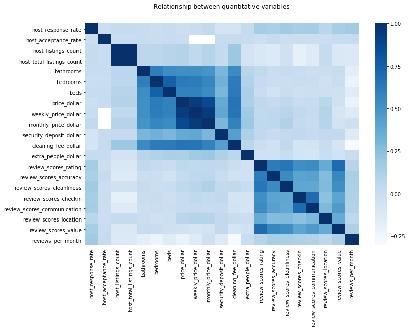

```python
plt.figure(figsize=[12,8])

sns.heatmap(listings_clean.select_dtypes(include=['float','int']).corr(), annot=False, cmap='Blues');

plt.title('Relationship between quantitative variables')

plt.savefig('Relationship.png', bbox_inches='tight')
```

From the above co-relation matrix, it looks like the following numerical features are impacting listing price the most:

1. bathrooms
2. bedrooms
3. beds
4. security_deposit
5. cleaning_fee_dollar

The monthly_price_dollar and weekly_price_dollar are similar response variables to price_dollar so we will skip them.

Let us drop the other numerical variables

```python
listings_clean.drop(columns=['host_response_rate','host_acceptance_rate','host_listings_count','weekly_price_dollar','monthly_price_dollar','extra_people_dollar','review_scores_accuracy','review_scores_cleanliness','review_scores_checkin','review_scores_communication','review_scores_value','reviews_per_month','host_thumbnail_url_flag','thumbnail_url_flag','host_picture_url_flag','xl_picture_url_flag','medium_url_flag'],inplace=True)
```

```python
listings_clean.head()
```

| id | host_is_superhost | host_total_listings_count | host_has_profile_pic | host_identity_verified | neighbourhood_group_cleansed | property_type | room_type | accommodates | bathrooms | bedrooms | beds | bed_type | price_dollar | security_deposit_dollar | cleaning_fee_dollar | guests_included | minimum_nights | maximum_nights | availability_30 | availability_60 | availability_90 | availability_365 | number_of_reviews | review_scores_rating | review_scores_location | instant_bookable | cancellation_policy | require_guest_profile_picture | require_guest_phone_verification | … |
| --- | --- | --- | --- | --- | --- | --- | --- | --- | --- | --- | --- | --- | --- | --- | --- | --- | --- | --- | --- | --- | --- | --- | --- | --- | --- | --- | --- | --- | --- | --- |
| 241032 | f | 3.0 | t | t | Queen Anne | Apartment | Entire home/apt | 4 | 1.0 | 1.0 | 1.0 | Real Bed | 85.0 | NaN | NaN | 2 | 1 | 365 | 14 | 41 | 71 | 346 | 207 | 95.0 | 9.0 | f | moderate | f | f | … |
| 953595 | t | 6.0 | t | t | Queen Anne | Apartment | Entire home/apt | 4 | 1.0 | 1.0 | 1.0 | Real Bed | 150.0 | 100.0 | 40.0 | 1 | 2 | 90 | 13 | 13 | 16 | 291 | 43 | 96.0 | 10.0 | f | strict | t | t | … |
| 3308979 | f | 2.0 | t | t | Queen Anne | House | Entire home/apt | 11 | 4.5 | 5.0 | 7.0 | Real Bed | 975.0 | 1000.0 | 300.0 | 10 | 4 | 30 | 1 | 6 | 17 | 220 | 20 | 97.0 | 10.0 | f | strict | f | f | … |
| 7421966 | f | 1.0 | t | t | Queen Anne | Apartment | Entire home/apt | 3 | 1.0 | 0.0 | 2.0 | Real Bed | 100.0 | NaN | NaN | 1 | 1 | 1125 | 0 | 0 | 0 | 143 | 0 | NaN | NaN | f | flexible | f | f | … |
| 278830 | f | 2.0 | t | t | Queen Anne | House | Entire home/apt | 6 | 2.0 | 3.0 | 3.0 | Real Bed | 450.0 | 700.0 | 125.0 | 6 | 1 | 1125 | 30 | 60 | 90 | 365 | 38 | 92.0 | 9.0 | f | strict | f | f | … |

```python
def create_dummy_df(df, cat_cols, dummy_na):
    '''
    INPUT:
    df - pandas dataframe with categorical variables you want to dummy
    cat_cols - list of strings that are associated with names of the categorical columns
    dummy_na - Bool holding whether you want to dummy NA vals of categorical columns or not

    OUTPUT:
    df - a new dataframe that has the following characteristics:
            1. contains all columns that were not specified as categorical
            2. removes all the original columns in cat_cols
            3. dummy columns for each of the categorical columns in cat_cols
            4. if dummy_na is True - it also contains dummy columns for the NaN values
            5. Use a prefix of the column name with an underscore (_) for separating

    Reference: Notebook + Quiz: Putting it all Together
    '''
    for col in  cat_cols:
        try:
            # for each cat add dummy var, drop original column
            df = pd.concat([df.drop(col, axis=1), pd.get_dummies(df[col], prefix=col, prefix_sep='_', drop_first=True, dummy_na=dummy_na)], axis=1)
        except:
            continue
    return df
```

```python
def clean_fit_linear_mod(df, response_col, cat_cols,mode_cols, mean_cols, dummy_na,test_size=.3, rand_state=42):
    '''
    INPUT:
    df - a dataframe holding all the variables of interest
    response_col - a string holding the name of the column
    cat_cols - list of strings that are associated with names of the categorical columns
    mode_cols - list of strings that are associated with the names of numerical columns, where null value will be replaced with mode
    mean_cols - list of strings that are associated with the names of numerical columns, where null value will be replaced with mean
    dummy_na - Bool holding whether you want to dummy NA vals of categorical columns or not
    test_size - a float between [0,1] about what proportion of data should be in the test dataset
    rand_state - an int that is provided as the random state for splitting the data into training and test

    OUTPUT:
    test_score - float - r2 score on the test data
    train_score - float - r2 score on the test data
    lm_model - model object from sklearn
    X_train, X_test, y_train, y_test - output from sklearn train test split used for optimal model

    Your function should:
    1. Drop the rows with missing response values
    2. Drop columns with NaN for all the values
    3. Use create_dummy_df to dummy categorical columns
    4. Fill the mean of the column for any missing values
    5. Split your data into an X matrix and a response vector y
    6. Create training and test sets of data
    7. Instantiate a LinearRegression model with normalized data
    8. Fit your model to the training data
    9. Predict the response for the training data and the test data
    10. Obtain an rsquared value for both the training and test data

    Reference: Notebook + Quiz: Putting it all Together
    '''
    #Drop the rows with missing response values
    df  = df.dropna(subset=[response_col], axis=0)

    #Drop columns with all NaN values
    df = df.dropna(how='all', axis=1)

    #Dummy categorical variables
    df = create_dummy_df(df, cat_cols, dummy_na)

    # Mean function
    num_vars = df.select_dtypes(include=['float', 'int']).columns
    for col in mean_cols:
        df[col].fillna((df[col].mean()), inplace=True)

    # Mode function
    #num_vars = df.select_dtypes(include=['float', 'int']).columns
    for col in mode_cols:
        df[col].fillna((df[col].mode()[0]), inplace=True)


    #Split into explanatory and response variables
    X = df.drop(response_col, axis=1)
    y = df[response_col]

    #print(X.columns[X.isnull().mean()!=0])

    #Split into train and test
    X_train, X_test, y_train, y_test = train_test_split(X, y, test_size=test_size, random_state=rand_state)

    lm_model = LinearRegression(normalize=True) # Instantiate
    lm_model.fit(X_train, y_train) #Fit

    #Predict using your model
    y_test_preds = lm_model.predict(X_test)
    y_train_preds = lm_model.predict(X_train)

    #Score using your model
    test_score = r2_score(y_test, y_test_preds)
    train_score = r2_score(y_train, y_train_preds)

    return test_score, train_score, lm_model, X_train, X_test, y_train, y_test
```

```python
#let us look at all the numerical variables we have
listings_clean.select_dtypes(include=['float', 'int']).columns
```

```
Index(['host_total_listings_count', 'bathrooms', 'bedrooms', 'beds',
       'price_dollar', 'security_deposit_dollar', 'cleaning_fee_dollar',
       'review_scores_rating', 'review_scores_location'],
      dtype='object')
```

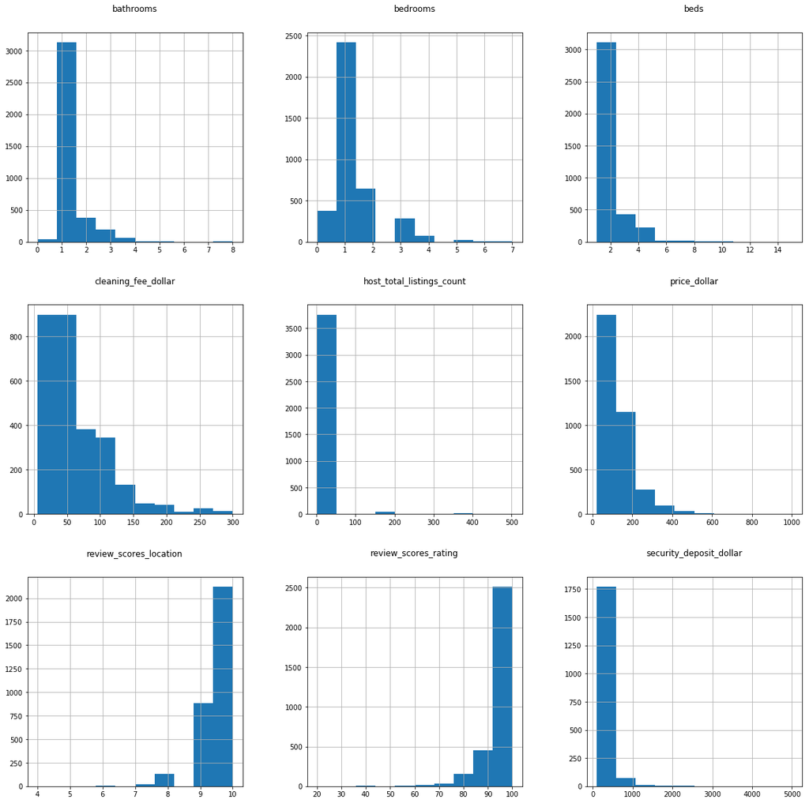

```python
listings_clean.select_dtypes(include=['float', 'int']).hist(figsize=[20,20]);
```

```python
listings_clean.bathrooms.value_counts()
```

```
1.0    2882
2.0     373
1.5     248
2.5     124
3.0      64
3.5      57
0.5      31
0.0       8
4.0       8
4.5       3
5.0       2
8.0       2
Name: bathrooms, dtype: int64
```

```python
listings_clean.beds.value_counts()
```

```
1.0     2201
2.0      912
3.0      433
4.0      152
5.0       73
6.0       21
7.0       14
8.0        4
9.0        4
10.0       2
15.0       1
Name: beds, dtype: int64
```

```python
listings_clean.host_total_listings_count.value_counts()
```

```
1.0      2179
2.0       620
3.0       261
4.0       151
5.0        98
34.0       67
6.0        48
48.0       46
169.0      39
37.0       37
36.0       36
7.0        30
9.0        28
10.0       26
8.0        23
11.0       22
21.0       21
18.0       19
17.0       16
13.0       12
12.0       12
354.0      10
19.0        4
163.0       4
15.0        3
84.0        2
502.0       2
Name: host_total_listings_count, dtype: int64
```

```python
listings_clean.review_scores_location.value_counts()
```

```
10.0    2122
9.0      884
8.0      129
7.0       19
6.0        8
4.0        1
Name: review_scores_location, dtype: int64
```

```python
np.log10(listings_clean.review_scores_rating).describe()
```

```
count    3171.000000
mean        1.974313
std         0.035769
min         1.301030
25%         1.968483
50%         1.982271
75%         1.995635
max         2.000000
Name: review_scores_rating, dtype: float64
```

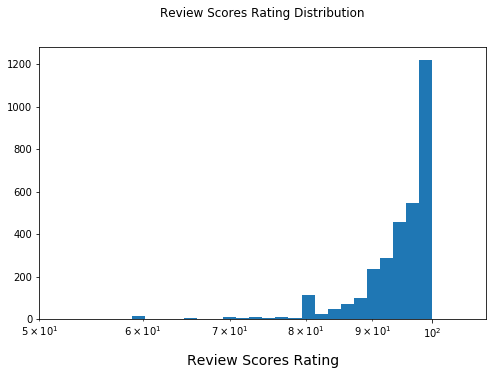

```python
#Review Scores Rating Distribution

plt.figure(figsize=[8, 5])

df = listings_clean[['review_scores_rating']]
df = df.dropna()

bins = 10 ** np.arange(1.3, np.log10(df.review_scores_rating.max())+0.01, 0.01);

y, x, _  = plt.hist(data = df,x = 'review_scores_rating', bins=bins);

plt.xscale('log')

plt.xlim(50,110);

plt.title('Review Scores Rating Distribution');
plt.xlabel('Review Scores Rating');

plt.grid(False);
```

```python
listings_clean.cleaning_fee_dollar.value_counts()
```

```
50.0     310
25.0     245
60.0     185
20.0     171
100.0    170
35.0     157
10.0     154
30.0     137
75.0     136
40.0     123
15.0     105
45.0      72
150.0     60
80.0      57
65.0      46
99.0      46
125.0     40
95.0      39
85.0      35
5.0       34
90.0      32
120.0     27
70.0      25
55.0      21
250.0     20
200.0     20
175.0     15
96.0      13
300.0     12
110.0     11
88.0      10
61.0      10
135.0     10
72.0       8
12.0       8
105.0      8
209.0      8
149.0      7
39.0       7
155.0      7
```

[output cut: 64 more lines]

```
142.0      1
210.0      1
134.0      1
179.0      1
137.0      1
189.0      1
185.0      1
52.0       1
76.0       1
42.0       1
27.0       1
68.0       1
21.0       1
117.0      1
Name: cleaning_fee_dollar, dtype: int64
```

```
[39.81071706] 510.0
```

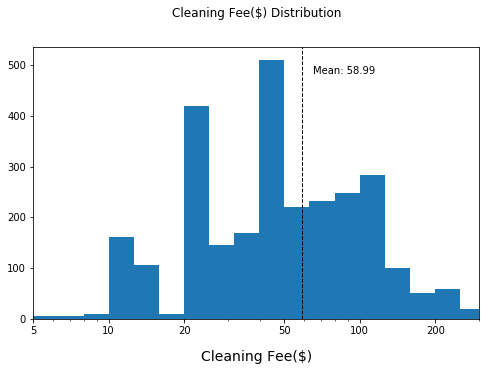

```python
#Cleaning Fee Distribution

plt.figure(figsize=[8, 5])

df = listings_clean[['cleaning_fee_dollar']]
df = df.dropna()

bins = 10 ** np.arange(0, np.log10(df.cleaning_fee_dollar.max())+0.1, 0.1);

y, x, _  = plt.hist(data = df,x = 'cleaning_fee_dollar', bins=bins);

plt.xscale('log')

plt.xticks([5,10, 20, 50, 100, 200, 500, 1000, 2000], [5,10, 20, 50, 100, 200, 500, 1000, 2000]);

plt.xlim(5,df.cleaning_fee_dollar.max());

plt.title('Cleaning Fee($) Distribution');
plt.xlabel('Cleaning Fee($)');

print(x[np.where(y == y.max())],y.max());

plt.axvline(x.mean(), color='k', linestyle='dashed', linewidth=1);

min_ylim, max_ylim = plt.ylim();

plt.text(x.mean()*1.1, max_ylim*0.9, 'Mean: {:.2f}'.format(x.mean()));

plt.grid(False);
```

**Null values by Imputing** We have 8 numerical variables where we need to fill the null values by imputing:

Cleaning_fee_dollar is right skewed multimodal distribution, so we will replace it with mode as well.

We do not observe any normal distribution so I will not use mean value for imputing.

bathrooms : Mode  
bedrooms : Mode  
beds : Mode  
host_total_listings_count : Mode  
security_deposit : Mode  
cleaning_fee_dollar : mode  
review_scores_rating : Mode  
review_scores_location : Mode

```python
#Dropping where the price has missing values
df  = listings_clean.dropna(subset=['price_dollar'], axis=0)

#create a list of columns where mode value needs to be applied
mode_cols_lst = {'cleaning_fee_dollar','security_deposit_dollar','bathrooms','bedrooms','beds','host_total_listings_count','review_scores_location','review_scores_rating'}

#create a list of columns where mean value needs to be applied
mean_cols_lst = {}


#create a list of categorical and boolean variables
cat_df = df.select_dtypes(include=['object','bool'])
cat_cols_lst = cat_df.columns

df_new = create_dummy_df(df, cat_cols_lst, dummy_na=False) #Use your newly created function

# Show a header of df_new to check
print(df_new.shape)
```

```
(3818, 112)
```

```python
#Test your function with the above dataset
test_score, train_score, lm_model, X_train, X_test, y_train, y_test = clean_fit_linear_mod(df, 'price_dollar', cat_cols_lst, mode_cols_lst, mean_cols_lst,dummy_na=False)
```

```python
#Print training and testing score
print("The rsquared on the training data was {}.  The rsquared on the test data was {}.".format(train_score, test_score))
```

```
The rsquared on the training data was 0.6143211765638148.  The rsquared on the test data was 0.6151971060502026.
```

**The r-square of training data is 61.43% and test data is 61.51%**

```python
def coef_weights(coefficients, X_train):
    '''
    INPUT:
    coefficients - the coefficients of the linear model
    X_train - the training data, so the column names can be used
    OUTPUT:
    coefs_df - a dataframe holding the coefficient, estimate, and abs(estimate)

    Provides a dataframe that can be used to understand the most influential coefficients
    in a linear model by providing the coefficient estimates along with the name of the
    variable attached to the coefficient.

    Reference: Notebook + Quiz: Putting it all Together
    '''
    coefs_df = pd.DataFrame()
    coefs_df['est_int'] = X_train.columns
    coefs_df['coefs'] = lm_model.coef_
    coefs_df['abs_coefs'] = np.abs(lm_model.coef_)
    coefs_df = coefs_df.sort_values('abs_coefs', ascending=False)
    return coefs_df

#Use the function
coef_df = coef_weights(lm_model.coef_, X_train)

#A quick look at the top results
coef_df.head(20)
```

|  | est_int | coefs | abs_coefs |
| --- | --- | --- | --- |
| 39 | property_type_Boat | 133.772370 | 133.772370 |
| 54 | room_type_Shared room | -68.959645 | 68.959645 |
| 42 | property_type_Camper/RV | 59.655195 | 59.655195 |
| 53 | room_type_Private room | -35.582698 | 35.582698 |
| 27 | neighbourhood_group_cleansed_Downtown | 30.546159 | 30.546159 |
| 47 | property_type_Loft | 30.313459 | 30.313459 |
| 49 | property_type_Tent | -29.442234 | 29.442234 |
| 109 | amenities_Doorman_True | 29.294779 | 29.294779 |
| 30 | neighbourhood_group_cleansed_Magnolia | 28.393819 | 28.393819 |
| 24 | neighbourhood_group_cleansed_Cascade | 27.333813 | 27.333813 |
| 23 | neighbourhood_group_cleansed_Capitol Hill | 27.215826 | 27.215826 |
| 3 | bedrooms | 25.343388 | 25.343388 |
| 33 | neighbourhood_group_cleansed_Queen Anne | 25.171339 | 25.171339 |
| 31 | neighbourhood_group_cleansed_Northgate | -25.164674 | 25.164674 |
| 2 | bathrooms | 21.139653 | 21.139653 |
| 45 | property_type_Dorm | -20.912862 | 20.912862 |
| 51 | property_type_Treehouse | 20.223443 | 20.223443 |
| 34 | neighbourhood_group_cleansed_Rainier Valley | -18.809159 | 18.809159 |
| 41 | property_type_Cabin | 18.622520 | 18.622520 |
| 56 | bed_type_Futon | -17.352288 | 17.352288 |

**From the above coefficients, it is clear that property type, room type, neighborhood_group, amenities_Doorman,bedrooms, bathrooms and bed type has the strongest co-relation with price. We will look at these proerties in detail.**

**1. Listing Price($/day) Distribution**

```python
#Understand the price distribution
listings_clean[['price_dollar']].describe()
```

|  | price_dollar |
| --- | --- |
| count | 3818.000000 |
| mean | 127.976166 |
| std | 90.250022 |
| min | 20.000000 |
| 25% | 75.000000 |
| 50% | 100.000000 |
| 75% | 150.000000 |
| max | 1000.000000 |

```python
# A log distributon is better suited to plot the listing price
np.log10(listings_clean[['price_dollar']]).describe()
```

|  | price_dollar |
| --- | --- |
| count | 3818.000000 |
| mean | 2.032163 |
| std | 0.245605 |
| min | 1.301030 |
| 25% | 1.875061 |
| 50% | 2.000000 |
| 75% | 2.176091 |
| max | 3.000000 |

```
[79.43282347] 691.0
```

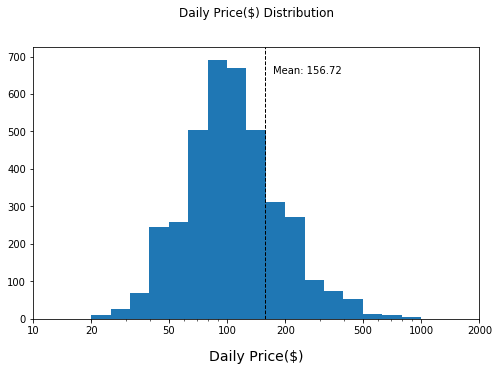

```python
#Price Distribution

plt.figure(figsize=[8, 5])

df = listings_clean[['price_dollar']]
df = df.dropna()

bins = 10 ** np.arange(0, np.log10(df.price_dollar.max())+0.1, 0.1);

y, x, _  = plt.hist(data = df,x = 'price_dollar', bins=bins);

plt.xscale('log')

plt.xticks([10, 20, 50, 100, 200, 500, 1000, 2000], [10, 20, 50, 100, 200, 500, 1000, 2000]);

plt.xlim(10,2000);

plt.title('Daily Price($) Distribution');
plt.xlabel('Daily Price($)');

print(x[np.where(y == y.max())],y.max());

plt.axvline(x.mean(), color='k', linestyle='dashed', linewidth=1);

min_ylim, max_ylim = plt.ylim();

plt.text(x.mean()*1.1, max_ylim*0.9, 'Mean: {:.2f}'.format(x.mean()));

plt.grid(False);

plt.savefig('DailyPriceDistribution.png', bbox_inches='tight')
```

```python
#Get the percentage of mode of value
691 /df.shape[0]
```

```
0.18098480880041906
```

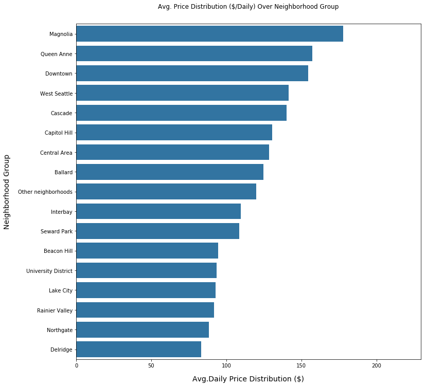

```python
plt.figure(figsize=[12,12])

order = listings_clean.groupby('neighbourhood_group_cleansed').price_dollar.mean().sort_values(ascending=False).index
sns.barplot(data = listings_clean, y = 'neighbourhood_group_cleansed', x='price_dollar', color = base_color,errwidth=False,order = order)
plt.xlabel('Avg.Daily Price Distribution ($)')
plt.title('Avg. Price Distribution ($/Daily) Over Neighborhood Group')
plt.ylabel('Neighborhood Group')


plt.savefig('PricePerNeighborhood.png', bbox_inches='tight')
plt.show()
```

From, the coefficients and above chart, we can infer that:

1. Magnolia has the the highest daily average listing price, followed be Queen Anne and Downtown.
2. Northgate has negative coefficient with price, indicating this is a cheaper area to stay in. The same can be said about Rainer Valley.
3. Downtown has the strongest positive co-relation with price.

**4. Mean Pricing and Mean Rating of Listings with different Amenities**

```python
#select amenities
amenities = listings_clean[['price_dollar','amenities_TV','amenities_Cable_TV','amenities_Internet','amenities_Wireless_Internet','amenities_Air_Conditioning','amenities_Kitchen','amenities_Heating','amenities_Family/Kid_Friendly','amenities_Washer','amenities_Dryer','amenities_Free_Parking_on_Premises','amenities_Buzzer/Wireless_Intercom','amenities_Smoke_Detector','amenities_Carbon_Monoxide_Detector','amenities_First_Aid_Kit','amenities_Safety_Card','amenities_Fire_Extinguisher','amenities_Essentials','amenities_Pets_Allowed','amenities_Pets_live_on_this_property','amenities_Dog(s)','amenities_Cat(s)','amenities_Hot_Tub','amenities_Indoor_Fireplace','amenities_Shampoo','amenities_Breakfast','amenities_24-Hour_Check-in','amenities_Hangers','amenities_Hair_Dryer','amenities_Iron','amenities_Laptop_Friendly_Workspace','amenities_Suitable_for_Events','amenities_Elevator_in_Building','amenities_Lock_on_Bedroom_Door','amenities_Wheelchair_Accessible','amenities_Gym','amenities_Pool','amenities_Smoking_Allowed','amenities_Other_pet(s)','amenities_Doorman','amenities_Washer_/_Dryer']]
```

```python
#calculate count per amenity and transpose the table
df = amenities.apply(pd.Series.value_counts,normalize=True).mul(100).T

#create a new field amenities from the index
df['amenities']=df.index

#select the first 2 columns (True and False)
df = df.iloc[:, 0:2]

#for each column , calculate the average daily price in $
for column in amenities.columns[2:]:

        col='Mean_Price($/day)'
        df.at[column,col] = amenities[amenities[column] == True].price_dollar.mean()


#Remove the False column
df = df.iloc[:, [1,2]]

#Skip the rating row in amenities
df = df.dropna(axis=0)

#Rename Columns
df['With Amenity(%)'] = df.iloc[:,:1]
df = df.iloc[:,[1,2]]

#Sort by mean daily listing price
df = df.sort_values(ascending=False , by='Mean_Price($/day)')

df['Amenity'] = df.index.str.replace('amenities_','')

columnsTitles = ['Amenity', 'With Amenity(%)', 'Mean_Price($/day)']

frame = df.reindex(columns=columnsTitles)

#set color
frame.style.background_gradient(cmap='Greens', low=0, high=0.8)\
.background_gradient(subset=['Mean_Price($/day)'],cmap='Blues', low=0, high=0.9).hide_index()
```

| Amenity | With Amenity(%) | Mean_Price($/day) |
| --- | --- | --- |
| Doorman | 2.2263 | 200.259 |
| Pool | 4.16448 | 170.893 |
| Hot_Tub | 7.93609 | 167.03 |
| Suitable_for_Events | 5.47407 | 160.574 |
| Gym | 11.5767 | 156.346 |
| Cable_TV | 37.8732 | 155.403 |
| Air_Conditioning | 17.7318 | 153.297 |
| Indoor_Fireplace | 23.2059 | 152.348 |
| Family/Kid_Friendly | 51.4144 | 150.775 |
| Pets_Allowed | 12.3625 | 147.246 |
| Elevator_in_Building | 20.5605 | 144.589 |
| Wheelchair_Accessible | 7.85752 | 143.077 |
| Safety_Card | 19.0414 | 137.813 |
| Buzzer/Wireless_Intercom | 14.0911 | 136.375 |
| Free_Parking_on_Premises | 56.7575 | 134.231 |
| Dryer | 78.4966 | 133.861 |
| Washer | 78.3656 | 133.712 |
| Iron | 19.4343 | 133.035 |
| Internet | 73.6249 | 132.096 |
| Fire_Extinguisher | 57.517 | 131.966 |
| Kitchen | 89.6543 | 131.809 |
| 24-Hour_Check-in | 16.1341 | 131.568 |
| Carbon_Monoxide_Detector | 65.0864 | 131.437 |
| Hair_Dryer | 20.2724 | 131.287 |
| Shampoo | 69.9319 | 129.882 |
| Laptop_Friendly_Workspace | 19.5128 | 129.809 |
| Smoke_Detector | 85.935 | 128.848 |
| Wireless_Internet | 96.045 | 128.478 |
| Heating | 94.9974 | 128.33 |
| First_Aid_Kit | 44.0021 | 128.279 |
| Hangers | 22.1582 | 127.755 |
| Essentials | 84.7826 | 127.225 |
| Dog(s) | 13.3316 | 117.621 |
| Other_pet(s) | 1.33578 | 111.176 |
| Pets_live_on_this_property | 23.1273 | 109.703 |
| Cat(s) | 10.0052 | 102.984 |
| Washer_/_Dryer | 0.0523834 | 102 |
| Breakfast | 7.62179 | 95.6289 |
| Smoking_Allowed | 2.14772 | 93.1341 |
| Lock_on_Bedroom_Door | 2.61917 | 74.14 |

**5. Type of Listings**

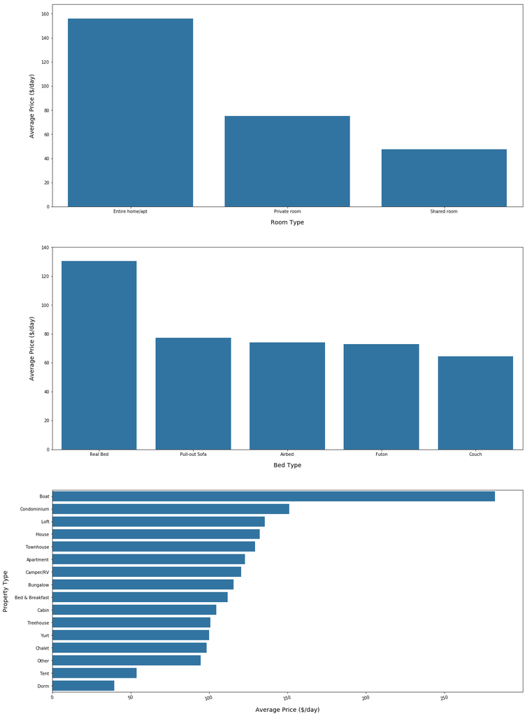

```python
listing_type=listings_clean[['price_dollar','property_type','room_type','bed_type']]

# plot matrix of arrival issues against year.
fig, ax = plt.subplots(nrows=3,ncols=1, figsize = [20,30])

order1 = listing_type.groupby('room_type').price_dollar.mean().sort_values(ascending=False)
plt1 = sns.barplot(data = listing_type, x = 'room_type',y='price_dollar', color = base_color, ax = ax[0],errwidth=False,order = order1.index)
plt1.set_xlabel('Room Type')
plt1.set_ylabel('Average Price ($/day)')

order1 = listing_type.groupby('bed_type').price_dollar.mean().sort_values(ascending=False)
plt1 = sns.barplot(data = listing_type, x = 'bed_type',y='price_dollar', color = base_color, ax = ax[1],errwidth=False,order = order1.index)
plt1.set_xlabel('Bed Type')
plt1.set_ylabel('Average Price ($/day)');


order1 = listing_type.groupby('property_type').price_dollar.mean().sort_values(ascending=False)
plt1 = sns.barplot(data = listing_type, y = 'property_type',x='price_dollar', color = base_color, ax = ax[2],errwidth=False,order = order1.index)
plt1.set_ylabel('Property Type')
plt1.set_xlabel('Average Price ($/day)')
plt1.set_xlim(0,300)
plt1.set_xticks(np.arange(0,300,50))

plt.savefig('PriceListing.png', bbox_inches='tight')

plt.xticks(rotation=15);
```

We can conclude from the above graphs that:

1. Boats are highest priced property types with strongest positive corelation with price
2. Shared room have strongest negative corelation with price as shared rooms tend to be cheaper
3. Futon bed has strongest negative corelation amongst all bed types with price.

As the coefficients indicates relationship between bedrooms and bathrooms, we will plot them againt price and see thee the relationships.

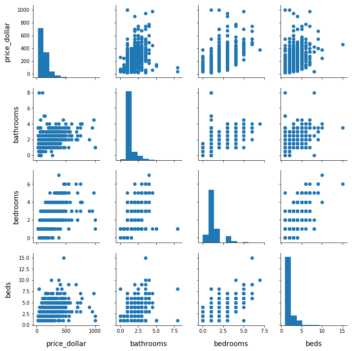

```python
#plot pair grids to see relationships
listing_type=listings_clean[['price_dollar','bathrooms','bedrooms','beds']].dropna()

g=sns.PairGrid(data=listing_type,vars=['price_dollar','bathrooms','bedrooms','beds'])
g=g.map_offdiag(plt.scatter)
g.map_diag(plt.hist);

plt.savefig('PriceRooms.png', bbox_inches='tight')
```

We can see from the graphs above, that :

1. All three variables beds, bedrooms and bathrooms are positively co-related with price.
2. There are cases that for the same number of bedrooms / bathrooms / beds, we observe different price ranges. This can be explained by different property types.
3. We also observe some extreme outliers e.g 8 bathrooms , however lower price, this could be shared rooms or dorms.
4. Another outlier we see is with 15 beds, however, less than \$500 per day

It would be interesting to plot these numerical variables with property type to understand the trends better.

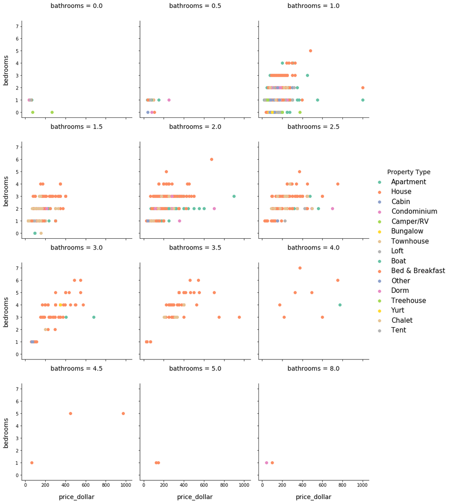

```python
plt.figure(figsize = [20,30]);

g=sns.FacetGrid(data=listings_clean,hue='property_type',palette='Set2',col='bathrooms',size=4,col_wrap=3,dropna=True);
g=g.map(plt.scatter,'price_dollar','bedrooms');
g.add_legend(title='Property Type');

plt.setp(g._legend.get_title(), fontsize=14);

plt.savefig('PriceRooms2.png', bbox_inches='tight');
```

From the above graphs, it is clear that listing with 8 bathrooms and 1 bedroom is a Dorm and a 'Bed & Breakfast'. This also explains the price lower than $200.

We also observe there are some listings with no bathrooms, like Treehouses, Lofts,etc.

1. How much does a listing with a pool cost all year round?

```python
# To understand yearwise price fluctuations we will take calendar data in addition
calendar = pd.read_csv('calendar_seattle.csv')
calendar.head(10)
```

|  | listing_id | date | available | price |
| --- | --- | --- | --- | --- |
| 0 | 241032 | 2016-01-04 | t | $85.00 |
| 1 | 241032 | 2016-01-05 | t | $85.00 |
| 2 | 241032 | 2016-01-06 | f | NaN |
| 3 | 241032 | 2016-01-07 | f | NaN |
| 4 | 241032 | 2016-01-08 | f | NaN |
| 5 | 241032 | 2016-01-09 | f | NaN |
| 6 | 241032 | 2016-01-10 | f | NaN |
| 7 | 241032 | 2016-01-11 | f | NaN |
| 8 | 241032 | 2016-01-12 | f | NaN |
| 9 | 241032 | 2016-01-13 | t | $85.00 |

```python
calendar.listing_id.nunique()
```

```
3818
```

```python
# Drop entries where price is not available
calendar.dropna(subset=['price'],inplace=True)
calendar.head()
```

|  | listing_id | date | available | price |
| --- | --- | --- | --- | --- |
| 0 | 241032 | 2016-01-04 | t | $85.00 |
| 1 | 241032 | 2016-01-05 | t | $85.00 |
| 9 | 241032 | 2016-01-13 | t | $85.00 |
| 10 | 241032 | 2016-01-14 | t | $85.00 |
| 14 | 241032 | 2016-01-18 | t | $85.00 |

```python
calendar.listing_id.nunique()
```

```
3723
```

We have 95 listings with no daily price available. We will skip them for analysis.

```python
#Let us convert date into date object into datetime
calendar.date = pd.to_datetime(calendar.date)

#We will now create a weekday column,month column and a year column
calendar['weekday'] = calendar.date.dt.day_name()

calendar['month'] = calendar.date.dt.month_name ()

calendar['year'] = calendar.date.dt.year

#we can drop the available column as we have already filtered out only available data
calendar.drop(columns=['available'],inplace=True)

col_lst= list({'price'})

#clean the dollar sign
clean_dollar(calendar,col_lst)
```

```python
#check output
calendar.head()
```

|  | listing_id | date | price_dollar | weekday | month | year |
| --- | --- | --- | --- | --- | --- | --- |
| 0 | 241032 | 2016-01-04 | 85.0 | Monday | January | 2016 |
| 1 | 241032 | 2016-01-05 | 85.0 | Tuesday | January | 2016 |
| 9 | 241032 | 2016-01-13 | 85.0 | Wednesday | January | 2016 |
| 10 | 241032 | 2016-01-14 | 85.0 | Thursday | January | 2016 |
| 14 | 241032 | 2016-01-18 | 85.0 | Monday | January | 2016 |

```python
listings_Pool = listings_clean[['bathrooms','bedrooms','beds','property_type','room_type','bed_type','amenities_TV','amenities_Cable_TV','amenities_Internet','amenities_Wireless_Internet','amenities_Air_Conditioning','amenities_Kitchen','amenities_Heating','amenities_Family/Kid_Friendly','amenities_Washer','amenities_Dryer','amenities_Free_Parking_on_Premises','amenities_Buzzer/Wireless_Intercom','amenities_Smoke_Detector','amenities_Carbon_Monoxide_Detector','amenities_First_Aid_Kit','amenities_Safety_Card','amenities_Fire_Extinguisher','amenities_Essentials','amenities_Pets_Allowed','amenities_Pets_live_on_this_property','amenities_Dog(s)','amenities_Cat(s)','amenities_Hot_Tub','amenities_Indoor_Fireplace','amenities_Shampoo','amenities_Breakfast','amenities_24-Hour_Check-in','amenities_Hangers','amenities_Hair_Dryer','amenities_Iron','amenities_Laptop_Friendly_Workspace','amenities_Suitable_for_Events','amenities_Elevator_in_Building','amenities_Lock_on_Bedroom_Door','amenities_Wheelchair_Accessible','amenities_Gym','amenities_Pool','amenities_Smoking_Allowed','amenities_Other_pet(s)','amenities_Doorman','amenities_Washer_/_Dryer']]

listings_Pool.head()
```

| id | bathrooms | bedrooms | beds | property_type | room_type | bed_type | amenities_TV | amenities_Cable_TV | amenities_Internet | amenities_Wireless_Internet | amenities_Air_Conditioning | amenities_Kitchen | amenities_Heating | amenities_Family/Kid_Friendly | amenities_Washer | amenities_Dryer | amenities_Free_Parking_on_Premises | amenities_Buzzer/Wireless_Intercom | amenities_Smoke_Detector | amenities_Carbon_Monoxide_Detector | amenities_First_Aid_Kit | amenities_Safety_Card | amenities_Fire_Extinguisher | amenities_Essentials | amenities_Pets_Allowed | amenities_Pets_live_on_this_property | amenities_Dog(s) | amenities_Cat(s) | amenities_Hot_Tub | … |
| --- | --- | --- | --- | --- | --- | --- | --- | --- | --- | --- | --- | --- | --- | --- | --- | --- | --- | --- | --- | --- | --- | --- | --- | --- | --- | --- | --- | --- | --- | --- |
| 241032 | 1.0 | 1.0 | 1.0 | Apartment | Entire home/apt | Real Bed | True | True | True | True | True | True | True | True | True | True | False | False | False | False | False | False | False | False | False | False | False | False | False | … |
| 953595 | 1.0 | 1.0 | 1.0 | Apartment | Entire home/apt | Real Bed | True | False | True | True | False | True | True | True | True | True | True | True | True | True | True | True | True | True | False | False | False | False | False | … |
| 3308979 | 4.5 | 5.0 | 7.0 | House | Entire home/apt | Real Bed | True | True | True | True | True | True | True | True | True | True | True | False | True | True | False | False | False | True | True | True | True | True | True | … |
| 7421966 | 1.0 | 0.0 | 2.0 | Apartment | Entire home/apt | Real Bed | False | False | True | True | False | True | True | True | True | True | False | False | True | True | False | True | True | True | False | False | False | False | False | … |
| 278830 | 2.0 | 3.0 | 3.0 | House | Entire home/apt | Real Bed | True | True | True | True | False | True | True | True | False | False | False | False | True | True | True | False | True | True | False | False | False | False | False | … |

```python
#We now need the amenities_Pool from the listings table to join in the calender dataframe to understand which listings have pool
calendar = calendar.join(listings_Pool,on='listing_id',how='left')
calendar.head()
```

|  | listing_id | date | price_dollar | weekday | month | year | bathrooms | bedrooms | beds | property_type | room_type | bed_type | amenities_TV | amenities_Cable_TV | amenities_Internet | amenities_Wireless_Internet | amenities_Air_Conditioning | amenities_Kitchen | amenities_Heating | amenities_Family/Kid_Friendly | amenities_Washer | amenities_Dryer | amenities_Free_Parking_on_Premises | amenities_Buzzer/Wireless_Intercom | amenities_Smoke_Detector | amenities_Carbon_Monoxide_Detector | amenities_First_Aid_Kit | amenities_Safety_Card | amenities_Fire_Extinguisher | … |
| --- | --- | --- | --- | --- | --- | --- | --- | --- | --- | --- | --- | --- | --- | --- | --- | --- | --- | --- | --- | --- | --- | --- | --- | --- | --- | --- | --- | --- | --- | --- |
| 0 | 241032 | 2016-01-04 | 85.0 | Monday | January | 2016 | 1.0 | 1.0 | 1.0 | Apartment | Entire home/apt | Real Bed | True | True | True | True | True | True | True | True | True | True | False | False | False | False | False | False | False | … |
| 1 | 241032 | 2016-01-05 | 85.0 | Tuesday | January | 2016 | 1.0 | 1.0 | 1.0 | Apartment | Entire home/apt | Real Bed | True | True | True | True | True | True | True | True | True | True | False | False | False | False | False | False | False | … |
| 9 | 241032 | 2016-01-13 | 85.0 | Wednesday | January | 2016 | 1.0 | 1.0 | 1.0 | Apartment | Entire home/apt | Real Bed | True | True | True | True | True | True | True | True | True | True | False | False | False | False | False | False | False | … |
| 10 | 241032 | 2016-01-14 | 85.0 | Thursday | January | 2016 | 1.0 | 1.0 | 1.0 | Apartment | Entire home/apt | Real Bed | True | True | True | True | True | True | True | True | True | True | False | False | False | False | False | False | False | … |
| 14 | 241032 | 2016-01-18 | 85.0 | Monday | January | 2016 | 1.0 | 1.0 | 1.0 | Apartment | Entire home/apt | Real Bed | True | True | True | True | True | True | True | True | True | True | False | False | False | False | False | False | False | … |

```python
# Let us look at how many unique households have pool
pool_counts = calendar.groupby('amenities_Pool').listing_id.nunique()
```

So have only 155 listings with a Pool and 3568 with no Pool

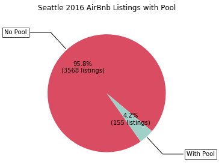

```python
#Display the percentage of listings with Pool
def func(pct, allvals):
    '''
    INPUT
    pct - numerator
    allvals - totals(demonimator)
    OUTPUT
    absolute : returns percentage of pct in allvals

    Function calculates the percentage of pct in allvals
    '''
    absolute = int(pct/100.*np.sum(allvals))
    return "{:.1f}%\n({:d} listings)".format(pct, absolute)

labels=['No Pool','With Pool']

wedges, texts, autotexts  = plt.pie(pool_counts, wedgeprops=dict(width=1), startangle=-40, autopct=lambda pct: func(pct, pool_counts),colors = ['#da4c62','#a0d0c8'])

bbox_props = dict(boxstyle="square,pad=0.3", fc="w", ec="k", lw=0.72)
kw = dict(arrowprops=dict(arrowstyle="-"),
          bbox=bbox_props, zorder=0, va="center")

for i, p in enumerate(wedges):
    ang = (p.theta2 - p.theta1)/2. + p.theta1
    y = np.sin(np.deg2rad(ang))
    x = np.cos(np.deg2rad(ang))
    horizontalalignment = {-1: "right", 1: "left"}[int(np.sign(x))]
    connectionstyle = "angle,angleA=0,angleB={}".format(ang)
    kw["arrowprops"].update({"connectionstyle": connectionstyle})
    plt.annotate(labels[i], xy=(x, y), xytext=(1.35*np.sign(x), 1.4*y),
               horizontalalignment=horizontalalignment, **kw)

plt.axis('square');

plt.title('Seattle 2016 AirBnb Listings with Pool');

plt.savefig('PoolDistribution.png', bbox_inches='tight')
```

```python
#Let us select the 4.2% listings with Pool for further analysis

with_pool = calendar.query('amenities_Pool == True')

with_pool.head()
```

|  | listing_id | date | price_dollar | weekday | month | year | bathrooms | bedrooms | beds | property_type | room_type | bed_type | amenities_TV | amenities_Cable_TV | amenities_Internet | amenities_Wireless_Internet | amenities_Air_Conditioning | amenities_Kitchen | amenities_Heating | amenities_Family/Kid_Friendly | amenities_Washer | amenities_Dryer | amenities_Free_Parking_on_Premises | amenities_Buzzer/Wireless_Intercom | amenities_Smoke_Detector | amenities_Carbon_Monoxide_Detector | amenities_First_Aid_Kit | amenities_Safety_Card | amenities_Fire_Extinguisher | … |
| --- | --- | --- | --- | --- | --- | --- | --- | --- | --- | --- | --- | --- | --- | --- | --- | --- | --- | --- | --- | --- | --- | --- | --- | --- | --- | --- | --- | --- | --- | --- |
| 102931 | 4868135 | 2016-01-05 | 159.0 | Tuesday | January | 2016 | 1.0 | 2.0 | 3.0 | Apartment | Entire home/apt | Real Bed | True | True | True | True | True | True | True | True | True | True | True | False | True | False | False | False | True | … |
| 102932 | 4868135 | 2016-01-06 | 159.0 | Wednesday | January | 2016 | 1.0 | 2.0 | 3.0 | Apartment | Entire home/apt | Real Bed | True | True | True | True | True | True | True | True | True | True | True | False | True | False | False | False | True | … |
| 102933 | 4868135 | 2016-01-07 | 159.0 | Thursday | January | 2016 | 1.0 | 2.0 | 3.0 | Apartment | Entire home/apt | Real Bed | True | True | True | True | True | True | True | True | True | True | True | False | True | False | False | False | True | … |
| 102934 | 4868135 | 2016-01-08 | 199.0 | Friday | January | 2016 | 1.0 | 2.0 | 3.0 | Apartment | Entire home/apt | Real Bed | True | True | True | True | True | True | True | True | True | True | True | False | True | False | False | False | True | … |
| 102935 | 4868135 | 2016-01-09 | 199.0 | Saturday | January | 2016 | 1.0 | 2.0 | 3.0 | Apartment | Entire home/apt | Real Bed | True | True | True | True | True | True | True | True | True | True | True | False | True | False | False | False | True | … |

```python
with_pool.year.value_counts()
```

```
2016    41826
2017      212
Name: year, dtype: int64
```

```python
with_pool.price_dollar.describe()
```

```
count    42038.000000
mean       222.778534
std        143.174671
min         30.000000
25%        132.000000
50%        183.000000
75%        279.000000
max        950.000000
Name: price_dollar, dtype: float64
```

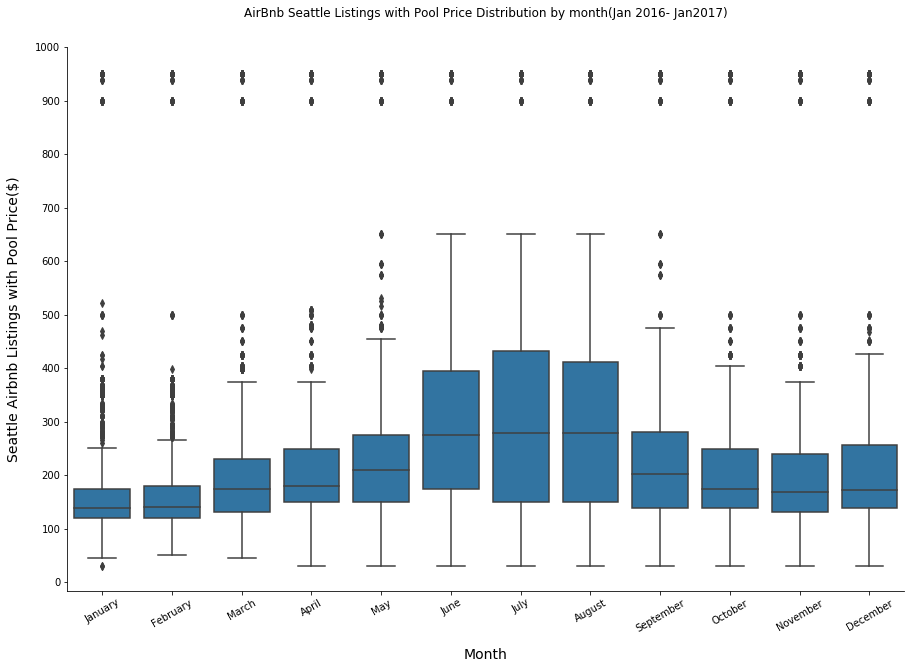

```python
#Let us look at average/min and max price per month

plt.figure(figsize=[15,10]);

sns.boxplot(data = with_pool, x = 'month',y='price_dollar', color = base_color);

plt.title('AirBnb Seattle Listings with Pool Price Distribution by month(Jan 2016- Jan2017)');

plt.xlabel('Month');

plt.ylabel('Seattle Airbnb Listings with Pool Price($)');

plt.xticks(rotation=30);

plt.yticks(np.arange(0,with_pool.price_dollar.max() + 100,100));

sns.despine(bottom = False, left = False)

plt.savefig('PoolPriceListing.png', bbox_inches='tight')
```

Let us look at how price fluctuates over weekdays.

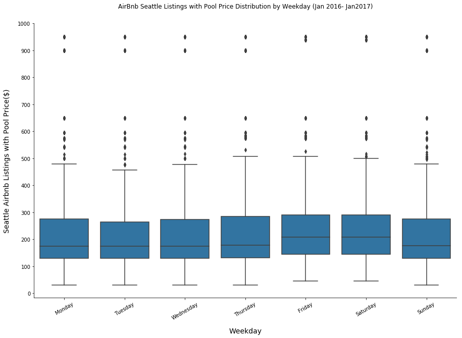

```python
#Let us look at average/min and max price per month

plt.figure(figsize=[15,10]);

order = ['Monday','Tuesday','Wednesday','Thursday','Friday','Saturday','Sunday']

sns.boxplot(data = with_pool, x = 'weekday',y='price_dollar', color = base_color, order=order);

plt.title('AirBnb Seattle Listings with Pool Price Distribution by Weekday (Jan 2016- Jan2017)');

plt.xlabel('Weekday');

plt.ylabel('Seattle Airbnb Listings with Pool Price($)');

plt.xticks(rotation=30);

plt.yticks(np.arange(0,with_pool.price_dollar.max() + 100,100));

sns.despine(bottom = False, left = False)

plt.savefig('PriceListingWeekDay.png', bbox_inches='tight')
```

This looks like Seattle is not much of a weekend gateway friendly for visitors. However, you can start your trip from Sunday onwards till mid-week if you want to save some costs.

From our earlier analysis, we observed that property types, bedrooms and bathrooms also influence price. Let us look at what listed properties have pool.

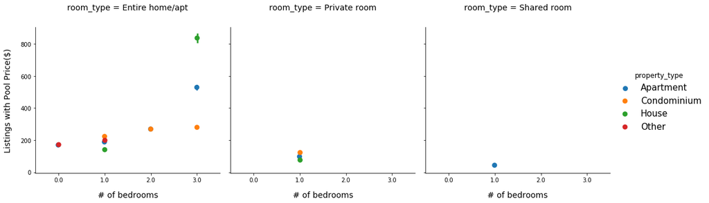

```python
order=[1,2,3,4]

g = sns.factorplot(x='bedrooms', y='price_dollar', hue='property_type', data=with_pool,
               col="room_type", col_wrap=3, size=5,
               dodge=0.01,sharex=False,kind='point',margin_titles=True,join=False)


g.set_xlabels('# of bedrooms');

g.set_ylabels('Listings with Pool Price($)');

plt.savefig('AppartmentTypesWithPools.png', bbox_inches='tight')
```